# PythonViz

We'll use pandas to input the data and manage it so we'll need to import that package.

```python
import pandas as pd
```

The statement below causes the matplotlib graphs to appear within the Jupter notebook rather than in a separate window that pops up. This can be very convenient because, among other reasons, the image will be retained in the notebook and computation will not be paused when many graphs are constructed within a loop. Statements that start with '%' are called magic functions. I think it is also fair to say that these are system-level commands that you might type in a DOS Command Window. The '%' indicates a system command so that it is executed properly. This web page talks about magis functions: https://stackoverflow.com/questions/20961287/what-is-pylab

```python
%matplotlib inline
```

These are the data we will be working with using the pandas DataFrame data type

df is often used as a variable name to denote a entity of the pandas DataFrame type

The pandas .read_csv() method is very useful. Note that the data files must have column headings in the first row.

The first data set below (stored in the df_oz DataFrame) is from William S. Cleveland and it is included in a typical R installation, whcih is my sources. These data describe temperature, wind speed, ozone, and radiation levels over time. The second data set, which is from the US Census web site, gives time series data for public (governmental) construction spending and private construction spending. The last data set, which is stored in the df_test DataFrame, gives high school standard of learning (SOL) scores for six course sections of a social studies course.

```python
df_oz = pd.read_csv('D:\\TeachingMaterials\\BusinessAnalytics\\Visualization\\VizData\\ozone.csv')
df_con = pd.read_csv('D:\\TeachingMaterials\\BusinessAnalytics\\Visualization\\VizData\\construction.csv')
df_test = pd.read_csv('D:\\TeachingMaterials\\BusinessAnalytics\\Visualization\\VizData\\test.csv')
```

Let's first look at the data in df_oz using the .head() method to see the first five rows of data.

```python
df_oz.head()
```

|  | ozone | radiation | temperature | wind |
| --- | --- | --- | --- | --- |
| 0 | 41 | 190 | 67 | 7.4 |
| 1 | 36 | 118 | 72 | 8.0 |
| 2 | 12 | 149 | 74 | 12.6 |
| 3 | 18 | 313 | 62 | 11.5 |
| 4 | 23 | 299 | 65 | 8.6 |

... and similarly for the other DataFrames...

```python
df_con.head()
```

|  | Month | Total Construction | Private Construction | Public Construction |
| --- | --- | --- | --- | --- |
| 0 | 1 | 59516 | 45273 | 14243 |
| 1 | 2 | 58588 | 44475 | 14113 |
| 2 | 3 | 63782 | 49396 | 14386 |
| 3 | 4 | 69504 | 53283 | 16221 |
| 4 | 5 | 73384 | 55009 | 18375 |

```python
df_test.head()
```

|  | StudentIdentifier | BegYearTestScore | EndYearTestScore | InstructorName | SchoolNumber | CourseSectionNumber |
| --- | --- | --- | --- | --- | --- | --- |
| 0 | 1 | 56 | 75 | Smith | 1 | 1 |
| 1 | 2 | 42 | 72 | Smith | 1 | 1 |
| 2 | 3 | 35 | 83 | Smith | 1 | 1 |
| 3 | 4 | 50 | 69 | Smith | 1 | 1 |
| 4 | 5 | 51 | 76 | Smith | 1 | 1 |

We will extract data series to plot from these pandas DataFrames but, first, let's do a very simple example of a matplotlib line chart with simpler data. The next statement imports the graphing package we will use and uses a very popular, if not ubiquitous alias, plt, for thsi matplotlib package.

```python
import matplotlib.pyplot as plt
```

Two lists are defined in the next block of code and plotted using the most basic of matplotlib commands.

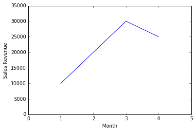

```python
x = [1,2,3,4]
y = [10000,20000, 30000, 25000]
plt.plot(x,y,label='Sales Revenue')   # 'Sales Revenue' is the label for the y data
plt.xlabel('Month')                   # Title for the horizontal axis
plt.ylabel('Sales Revenue')           # Title for the vertical axis
plt.axis([0,5,0,35000])               # sets the limits on the horizontal and vertical axes, respectively
plt.show()
```

Note that the graph above has a 'buffer' between the data and the graph frame, which is widely held as good aesthetic design. This is accomplished by defining the x and y axis limits.

The version below is more aesthetically pleasing because the x axis labels are the month acronyms rather than an integer. This is accomplished with the plt.xticks() statement. This code also has a statement to save the graphic as a .png file. You must include this statement before the plt.show() statement

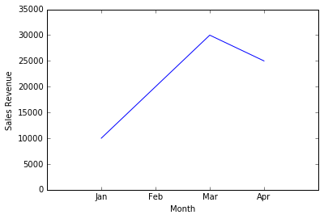

```python
x = [1,2,3,4]
x_labels = ['Jan','Feb','Mar','Apr']
y = [10000,20000, 30000, 25000]
plt.plot(x,y,label='Sales Revenue')   # 'Sales Revenue' is the label for the y data
plt.xlabel('Month')                   # Title for the horizontal axis
plt.ylabel('Sales Revenue')           # Title for the vertical axis
plt.xticks(x,x_labels)
plt.axis([0,5,0,35000])               # sets the limits on the horizontal and vertical axes, respectively
plt.savefig('sales.png')
plt.show()
```

We can extract a column of data from a DataFrame by using its name, as follows. In this case the data are from teh construction data set.

```python
df_con['Total Construction']
```

```
0      59516
1      58588
2      63782
3      69504
4      73384
5      77182
6      78863
7      79460
8      76542
9      75710
10     71362
11     63984
12     59877
13     58526
14     64506
```

[output cut: 47 more lines]

Now, let's adapt the plotting code above to the df_con DataFrame data... Note that Data Series are extracted from the pandas DataFrame using two different methods in the first two lines of the code.

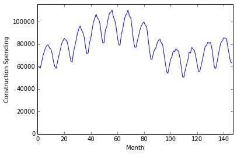

```python
x = df_con.Month
y = df_con['Total Construction']
plt.plot(x,y,label='Total Construction')
plt.xlabel('Month')                      # Title for the horizontal axis
plt.ylabel('Construction Spending')      # Title for the vertical axis
plt.axis([0,max(df_con['Month'])+1,0,max(df_con['Total Construction'])*1.05])    # Set ranges of axes
plt.show()
```

The df_oz DataFrame contains four climatic data series for New York City. Retrieve the column heading to see what they are.

```python
df_oz.columns.values
```

```
array(['ozone', 'radiation', 'temperature', 'wind'], dtype=object)
```

Let's investigate the relationship of ozone level to wind speed with a scatter plot.

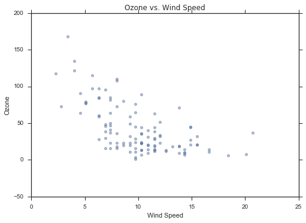

```python
""" Format of the scatterplot method is as follows: plt.scatter(x-series, y-series) """
plt.scatter(df_oz['wind'], df_oz['ozone'], alpha=0.5)
# alpha is a parameter that controls the transparency of the dots: 1 = solid, <1 = various transparency levels, 0 = no mark
plt.title('Ozone vs. Wind Speed')
plt.xlabel('Wind Speed')
plt.ylabel('Ozone')
plt.show()
```

Here's ozone level versus solar radiation. What relationship do you see?

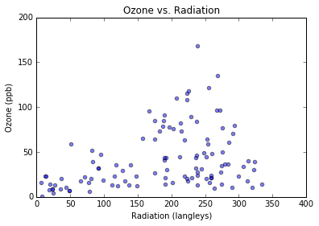

```python
""" Format of the scatterplot method is as follows: plt.scatter(x-series, y-series) """
plt.scatter(df_oz['radiation'], df_oz['ozone'], alpha=0.5)
# alpha is a parameter that controls the transparency of the dots: 1 = solid, <1 = various transparency levels, 0 = no mark
plt.title('Ozone vs. Radiation')
plt.xlabel('Radiation (langleys)')
plt.ylabel('Ozone (ppb)')
plt.axis([0,400,0,200])
plt.show()
```

Let's look at some distributional data from a database that contains student scores for two tests, one taken at the beginning of the year and one at the end of the year. Each student's scores are recorded along with their isntructor, school number, and course section number. Here are the column names:

```python
df_test.columns.values
```

```
array(['StudentIdentifier', 'BegYearTestScore', 'EndYearTestScore',
       'InstructorName', 'SchoolNumber', 'CourseSectionNumber'], dtype=object)
```

Here's what the data look like:

```python
df_test.head()
```

|  | StudentIdentifier | BegYearTestScore | EndYearTestScore | InstructorName | SchoolNumber | CourseSectionNumber |
| --- | --- | --- | --- | --- | --- | --- |
| 0 | 1 | 56 | 75 | Smith | 1 | 1 |
| 1 | 2 | 42 | 72 | Smith | 1 | 1 |
| 2 | 3 | 35 | 83 | Smith | 1 | 1 |
| 3 | 4 | 50 | 69 | Smith | 1 | 1 |
| 4 | 5 | 51 | 76 | Smith | 1 | 1 |

Before we proceed, let's clean things up a bit by using the StudentIdentifier data as the index. It is unnecessary to have both the (automatic) integer index and the StudentIdentifier.

```python
df_test1 = df_test.set_index('StudentIdentifier')
```

```python
df_test1.head()
```

| StudentIdentifier | BegYearTestScore | EndYearTestScore | InstructorName | SchoolNumber | CourseSectionNumber |
| --- | --- | --- | --- | --- | --- |
| 1 | 56 | 75 | Smith | 1 | 1 |
| 2 | 42 | 72 | Smith | 1 | 1 |
| 3 | 35 | 83 | Smith | 1 | 1 |
| 4 | 50 | 69 | Smith | 1 | 1 |
| 5 | 51 | 76 | Smith | 1 | 1 |

pandas provides an easy way, using the .unique() method, to find the distinct entries in each column, for example to find what instructors are represented in the database

```python
df_test1['InstructorName'].unique()
```

```
array(['Smith', 'Jones', 'Green'], dtype=object)
```

Let's filter the rows, choosing only those rows where Smith is the instructor

```python
df_test1.loc[df_test1['InstructorName'] == 'Smith']
```

| StudentIdentifier | BegYearTestScore | EndYearTestScore | InstructorName | SchoolNumber | CourseSectionNumber |
| --- | --- | --- | --- | --- | --- |
| 1 | 56 | 75 | Smith | 1 | 1 |
| 2 | 42 | 72 | Smith | 1 | 1 |
| 3 | 35 | 83 | Smith | 1 | 1 |
| 4 | 50 | 69 | Smith | 1 | 1 |
| 5 | 51 | 76 | Smith | 1 | 1 |
| 6 | 35 | 67 | Smith | 1 | 1 |
| 7 | 37 | 73 | Smith | 1 | 1 |
| 8 | 57 | 76 | Smith | 1 | 1 |
| 9 | 40 | 70 | Smith | 1 | 1 |
| 10 | 64 | 80 | Smith | 1 | 1 |
| 11 | 52 | 79 | Smith | 1 | 1 |
| 12 | 43 | 83 | Smith | 1 | 1 |
| 13 | 46 | 72 | Smith | 1 | 1 |
| 14 | 40 | 84 | Smith | 1 | 1 |
| 15 | 45 | 76 | Smith | 1 | 1 |
| 16 | 57 | 69 | Smith | 1 | 1 |
| 17 | 61 | 65 | Smith | 1 | 1 |
| 18 | 40 | 72 | Smith | 1 | 1 |
| 19 | 39 | 77 | Smith | 1 | 1 |
| 20 | 61 | 82 | Smith | 1 | 1 |
| 21 | 59 | 70 | Smith | 1 | 1 |
| 22 | 59 | 82 | Smith | 1 | 1 |
| 23 | 62 | 67 | Smith | 1 | 1 |
| 24 | 63 | 84 | Smith | 1 | 1 |
| 25 | 37 | 65 | Smith | 1 | 1 |
| 26 | 37 | 68 | Smith | 1 | 1 |
| 27 | 40 | 66 | Smith | 1 | 1 |
| 28 | 60 | 82 | Smith | 1 | 1 |
| 29 | 60 | 80 | Smith | 1 | 1 |
| 30 | 44 | 76 | Smith | 1 | 1 |
| ... | ... | ... | ... | ... | ... |
| 6 | 46 | 68 | Smith | 1 | 4 |
| 7 | 61 | 71 | Smith | 1 | 4 |
| 8 | 52 | 78 | Smith | 1 | 4 |
| 9 | 56 | 82 | Smith | 1 | 4 |
| 10 | 63 | 84 | Smith | 1 | 4 |
| 11 | 60 | 65 | Smith | 1 | 4 |
| 12 | 39 | 66 | Smith | 1 | 4 |
| 13 | 40 | 79 | Smith | 1 | 4 |
| 14 | 48 | 77 | Smith | 1 | 4 |
| 15 | 42 | 79 | Smith | 1 | 4 |
| 16 | 48 | 79 | Smith | 1 | 4 |
| 17 | 40 | 83 | Smith | 1 | 4 |
| 18 | 61 | 66 | Smith | 1 | 4 |
| 19 | 60 | 81 | Smith | 1 | 4 |
| 20 | 51 | 78 | Smith | 1 | 4 |
| 21 | 59 | 74 | Smith | 1 | 4 |
| 22 | 40 | 71 | Smith | 1 | 4 |
| 23 | 54 | 76 | Smith | 1 | 4 |
| 24 | 61 | 68 | Smith | 1 | 4 |
| 25 | 47 | 71 | Smith | 1 | 4 |
| 26 | 56 | 80 | Smith | 1 | 4 |
| 27 | 64 | 83 | Smith | 1 | 4 |
| 28 | 38 | 81 | Smith | 1 | 4 |
| 29 | 60 | 73 | Smith | 1 | 4 |
| 30 | 58 | 75 | Smith | 1 | 4 |
| 31 | 59 | 76 | Smith | 1 | 4 |
| 32 | 53 | 75 | Smith | 1 | 4 |
| 33 | 57 | 80 | Smith | 1 | 4 |
| 34 | 63 | 84 | Smith | 1 | 4 |
| 35 | 51 | 68 | Smith | 1 | 4 |

70 rows × 5 columns

Let's plot a frequency histogram of this data for the year end test scores.

```python
df_test1.loc[df_test1['InstructorName'] == 'Smith']['EndYearTestScore']
```

```
StudentIdentifier
1     75
2     72
3     83
4     69
5     76
6     67
7     73
8     76
9     70
10    80
11    79
12    83
13    72
14    84
```

[output cut: 48 more lines]

Here's a frequency histogram for Instructor Smith's students at the end of the school year.

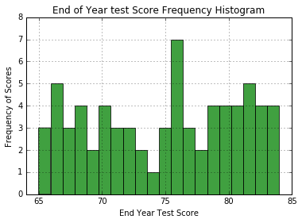

```python
plt.hist(x = df_test1.loc[df_test1['InstructorName'] == 'Smith']['EndYearTestScore'], bins = 20, facecolor='g', alpha=0.75)
plt.xlabel('End Year Test Score')
plt.ylabel('Frequency of Scores')
plt.title('End of Year test Score Frequency Histogram')
plt.axis([64, 85, 0, 8])
plt.grid(True)
plt.show()
```

Here's one way to show a comparison of Smith's and Green's student scores at the end of the year. Do you like the graph? Is it easy to read? Do you ahve any suggestions for improvement?

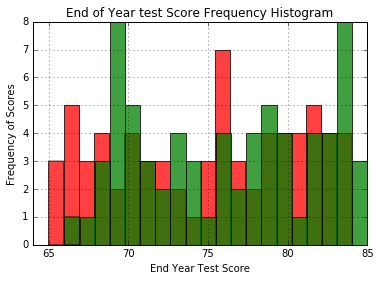

```python
plt.hist(x = df_test1.loc[df_test1['InstructorName'] == 'Smith']['EndYearTestScore'], bins = 20, facecolor='r', alpha=0.75)
plt.hist(x = df_test1.loc[df_test1['InstructorName'] == 'Green']['EndYearTestScore'], bins = 20, facecolor='g', alpha=0.75)
plt.xlabel('End Year Test Score')
plt.ylabel('Frequency of Scores')
plt.title('End of Year test Score Frequency Histogram')
plt.axis([64, 85, 0, 8])
plt.grid(True)
plt.show()
```

```python
import numpy as np
```

```python
df_test2 = pd.concat([df_test1.loc[df_test1['InstructorName'] == 'Smith']['EndYearTestScore'],df_test1.loc[df_test1['InstructorName'] == 'Green']['EndYearTestScore']], axis = 1)
df_test2.columns = ['Smith','Green']
```

```python
df_test1.loc[df_test1['InstructorName'] == 'Green']['EndYearTestScore']
```

```
StudentIdentifier
1     83
2     69
3     78
4     82
5     82
6     69
7     67
8     76
9     71
10    82
11    73
12    82
13    68
14    69
```

[output cut: 48 more lines]

```python
df_test2
```

| StudentIdentifier | Smith | Green |
| --- | --- | --- |
| 1 | 75 | 83 |
| 2 | 72 | 69 |
| 3 | 83 | 78 |
| 4 | 69 | 82 |
| 5 | 76 | 82 |
| 6 | 67 | 69 |
| 7 | 73 | 67 |
| 8 | 76 | 76 |
| 9 | 70 | 71 |
| 10 | 80 | 82 |
| 11 | 79 | 73 |
| 12 | 83 | 82 |
| 13 | 72 | 68 |
| 14 | 84 | 69 |
| 15 | 76 | 77 |
| 16 | 69 | 85 |
| 17 | 65 | 80 |
| 18 | 72 | 78 |
| 19 | 77 | 77 |
| 20 | 82 | 76 |
| 21 | 70 | 85 |
| 22 | 82 | 79 |
| 23 | 67 | 70 |
| 24 | 84 | 68 |
| 25 | 65 | 73 |
| 26 | 68 | 78 |
| 27 | 66 | 79 |
| 28 | 82 | 85 |
| 29 | 80 | 72 |
| 30 | 76 | 74 |
| ... | ... | ... |
| 6 | 68 | 83 |
| 7 | 71 | 73 |
| 8 | 78 | 69 |
| 9 | 82 | 70 |
| 10 | 84 | 78 |
| 11 | 65 | 66 |
| 12 | 66 | 83 |
| 13 | 79 | 69 |
| 14 | 77 | 80 |
| 15 | 79 | 84 |
| 16 | 79 | 84 |
| 17 | 83 | 71 |
| 18 | 66 | 74 |
| 19 | 81 | 73 |
| 20 | 78 | 70 |
| 21 | 74 | 69 |
| 22 | 71 | 70 |
| 23 | 76 | 84 |
| 24 | 68 | 74 |
| 25 | 71 | 84 |
| 26 | 80 | 81 |
| 27 | 83 | 80 |
| 28 | 81 | 83 |
| 29 | 73 | 70 |
| 30 | 75 | 84 |
| 31 | 76 | 76 |
| 32 | 75 | 84 |
| 33 | 80 | 84 |
| 34 | 84 | 69 |
| 35 | 68 | 76 |

70 rows × 2 columns

Here's a boxplot of Smith's end of year student test scores.

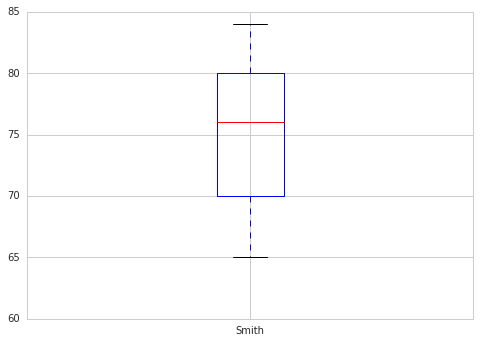

```python
# plt.boxplot will not take pandas dataframe data so data must be converted either to numpy array or a list
# the .as_matrix() method converts to a numpy array
# list() will convert a pandas series to a Python list
plt.boxplot(df_test1.loc[df_test1['InstructorName'] == 'Smith']['EndYearTestScore'].as_matrix())
plt.xticks([1],['Smith'])
plt.ylim([60,85])
plt.show()
```

Code for comparing Smith and Green

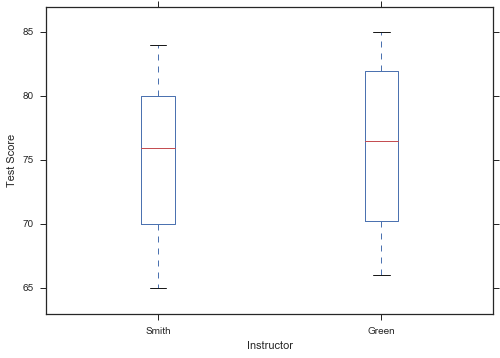

```python
data = []       # create an empty Python list; sublists will be appended for each boxplot
data.append(list(df_test1.loc[df_test1['InstructorName'] == 'Smith']['EndYearTestScore']))
data.append(list(df_test1.loc[df_test1['InstructorName'] == 'Green']['EndYearTestScore']))
plt.boxplot(data)
plt.xticks([1,2],['Smith','Green'])
data_min = min([min(sublist) for sublist in data])  # this and the following 3 lines automatically size the graph to the data
data_max = max([max(sublist) for sublist in data])  # while providing buffer space
plt.ylim([data_min - 2, data_max + 2])
plt.xlabel('Instructor')
plt.ylabel('Test Score')
plt.show()
```

Code for comparing Smith, Jones, and Green

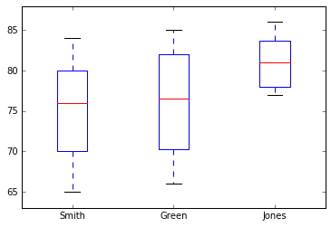

```python
data = []       # create an empty Python list; sublists will be appended for each boxplot
instructors = ['Smith','Green','Jones']
for instructor in instructors:
    data.append(list(df_test1.loc[df_test1['InstructorName'] == instructor]['EndYearTestScore']))
plt.boxplot(data)
plt.xticks(range(1,len(instructors)+1),instructors)
data_min = min([min(sublist) for sublist in data])  # this and the following 3 lines automatically size the graph to the data
data_max = max([max(sublist) for sublist in data])  # while providing buffer space
plt.ylim([data_min - 2, data_max + 2])
plt.show()
```

We will create a violin plot of this data using the seaborn package. The seaborn package interoperates with pandas data better than does matplotlib.

```python
import seaborn as sns
```

The line below will cause the graphs to appear within the jupyter window

```python
%matplotlib inline
```

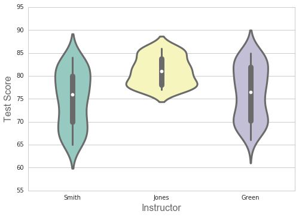

```python
#f, ax = plt.subplots(figsize=(8, 8))
sns.set_style("whitegrid")
sns.despine(left=True)
fig = sns.violinplot(x="InstructorName",y="EndYearTestScore",data=df_test1, inner="box", palette="Set3", cut=2, linewidth=3)
fig.set_xlabel("Instructor",size = 16,alpha=0.7)
fig.set_ylabel("Test Score",size = 16,alpha=0.7)
# note that matplotlib is operating in the background here and so we can use it to save teh figure to file
plt.savefig('instructors.png')
plt.show()
```

```python
pdata = [21, 2, 10, 4, 16]
```

```python
plabels = ['tom', 'betty', 'alyson', 'john', 'bob']
```

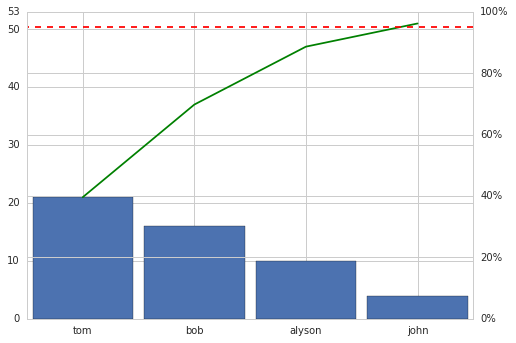

```python
from paretochart import pareto
pareto(pdata, plabels, limit=0.95, line_args=('g',))
```

```python
blabels = ['SS-Unemp','Medicare-Health','Mil.','Interest', 'Vet Benefits','Agri.','Edu','Trans','Housing','Intl Affairs','EnergyEnv','Science']
```

```python
bdata = [1.28,1.05,0.6093,0.22195,0.16063,0.1357,0.10226,0.08499,0.06148,0.05022,0.04485,0.02981]
```

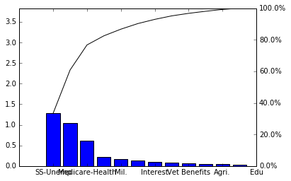

```python
import matplotlib.pyplot as plt

bdata_cum = []
for i in range(len(bdata)):
    bdata_cum.append(sum(bdata[0:i+1])/sum(bdata))
fig, ax = plt.subplots()
ax.set_xticklabels(['']+blabels)
xs = range(len(bdata))
ax.bar(xs,bdata, align='center')
ax.set_ylim(0,sum(bdata1))
ax1 = ax.twinx()
ax1.plot(xs,bdata_cum,color='k')
ax1.set_ylim(0,1)
ax1.set_yticklabels(['{:1.1f}%'.format(x*100) for x in ax1.get_yticks()])
plt.show()
```

```python
blabels1 = ['SS','Health','Mil.','Interest', 'Vet.','Agri.','Other']
```

```python
bindex = 6
bother = sum(bdata[bindex:])
bother
```

```
0.37361
```

```python
bdata1 = bdata[:bindex] + [bother]
```

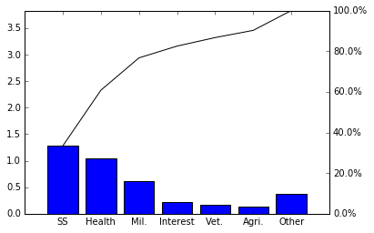

```python
import matplotlib.pyplot as plt

bdata_cum = []
for i in range(len(bdata1)):
    bdata_cum.append(sum(bdata1[0:i+1])/sum(bdata1))
fig, ax = plt.subplots()
ax.set_xticklabels(['']+blabels1)
xs = range(len(bdata1))
ax.bar(xs,bdata1, align='center')
ax.set_ylim(0,sum(bdata1))
ax1 = ax.twinx()
ax1.plot(xs,bdata_cum,color='k')
ax1.set_ylim(0,1)
ax1.set_yticklabels(['{:1.1f}%'.format(x*100) for x in ax1.get_yticks()])
plt.show()
```

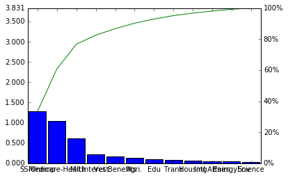

```python
from paretochart import pareto
pareto(bdata, blabels, line_args=('g',))
```

```python
blabels1 = ['SS','Health','Mil.','Interest', 'Vet.','Agri.','Other']
```

```python
bindex = 6
bother = sum(bdata[bindex:])
bother
```

```
0.37361
```

```python
bindex
```

```
6
```

```python
bdata1 = bdata[:bindex] + [bother]
```

```python
bdata1
```

```
[1.28, 1.05, 0.6093, 0.22195, 0.16063, 0.1357, 0.37361]
```

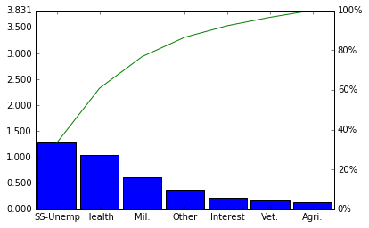

```python
from paretochart import pareto
pareto(bdata1, blabels1, line_args=('g',))
```

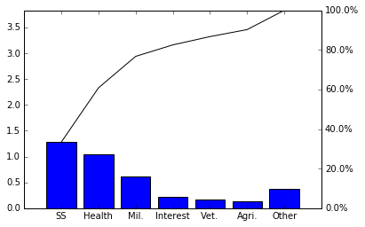

```python
import matplotlib.pyplot as plt

bdata_cum = []
for i in range(len(bdata1)):
    bdata_cum.append(sum(bdata1[0:i+1])/sum(bdata1))
fig, ax = plt.subplots()
ax.set_xticklabels(['']+blabels1)
xs = range(len(bdata1))
ax.bar(xs,bdata1, align='center')
ax.set_ylim(0,sum(bdata1))
ax1 = ax.twinx()
ax1.plot(xs,bdata_cum,color='k')
ax1.set_ylim(0,1)
ax1.set_yticklabels(['{:1.1f}%'.format(x*100) for x in ax1.get_yticks()])
plt.show()
```

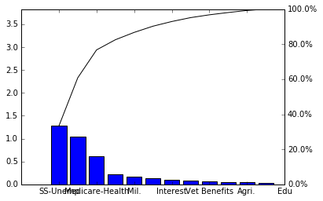

```python
import matplotlib.pyplot as plt

bdata_cum = []
for i in range(len(bdata)):
    bdata_cum.append(sum(bdata[0:i+1])/sum(bdata))
fig, ax = plt.subplots()
ax.set_xticklabels(['']+blabels)
xs = range(len(bdata))
ax.bar(xs,bdata, align='center')
ax.set_ylim(0,sum(bdata1))
ax1 = ax.twinx()
ax1.plot(xs,bdata_cum,color='k')
ax1.set_ylim(0,1)
ax1.set_yticklabels(['{:1.1f}%'.format(x*100) for x in ax1.get_yticks()])
plt.show()
```

```python
bdata_cum
```

[output not shown]

```python
ax1.get_yticks()
```

```
array([ 0. ,  0.2,  0.4,  0.6,  0.8,  1. ])
```

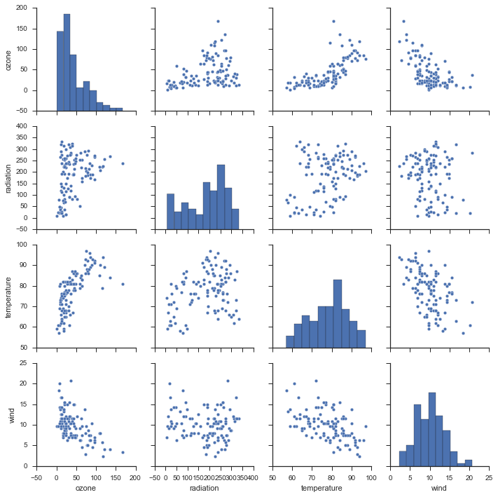

```python
sns.set(style="ticks", color_codes=True)
g = sns.pairplot(df_oz)
g.savefig('ozone.jpg')
```

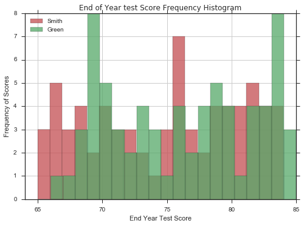

```python
plt.hist(x = df_test1.loc[df_test1['InstructorName'] == 'Smith']['EndYearTestScore'], bins = 20, facecolor='r', alpha=0.75)
plt.hist(x = df_test1.loc[df_test1['InstructorName'] == 'Green']['EndYearTestScore'], bins = 20, facecolor='g', alpha=0.75)
plt.xlabel('End Year Test Score')
plt.ylabel('Frequency of Scores')
plt.title('End of Year test Score Frequency Histogram')
plt.legend(['Smith','Green'], loc=2)
plt.axis([64, 85, 0, 8])
plt.grid(True)
plt.show()
```

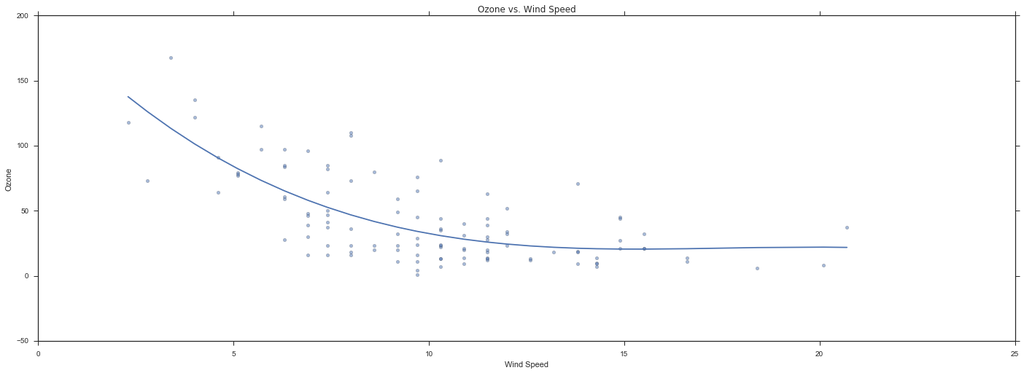

```python
""" Format of the scatterplot method is as follows: plt.scatter(x-series, y-series) """
plt.figure(figsize=(24,8))
plt.scatter(df_oz['wind'], df_oz['ozone'], alpha=0.5)
plt.plot(np.unique(df_oz['wind']), np.poly1d(np.polyfit(df_oz['wind'], df_oz['ozone'],3))(np.unique(df_oz['wind'])))
# alpha is a parameter that controls the transparency of the dots: 1 = solid, <1 = various transparency levels, 0 = no mark
plt.title('Ozone vs. Wind Speed')
plt.xlabel('Wind Speed')
plt.ylabel('Ozone')
plt.show()
```

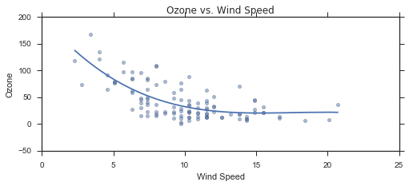

```python
""" Format of the scatterplot method is as follows: plt.scatter(x-series, y-series) """
plt.figure(figsize=(8,3))
plt.scatter(df_oz['wind'], df_oz['ozone'], alpha=0.5)
plt.plot(np.unique(df_oz['wind']), np.poly1d(np.polyfit(df_oz['wind'], df_oz['ozone'],3))(np.unique(df_oz['wind'])))
# alpha is a parameter that controls the transparency of the dots: 1 = solid, <1 = various transparency levels, 0 = no mark
plt.title('Ozone vs. Wind Speed')
plt.xlabel('Wind Speed')
plt.ylabel('Ozone')
plt.show()
```

```python
np.polyfit(df_oz['wind'], df_oz['ozone'],3)
```

```
array([ -3.50706878e-02,   1.84631274e+00,  -3.18805790e+01,
         2.01662531e+02])
```

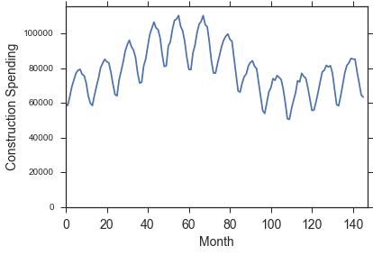

```python
x = df_con.index
y = df_con['Total Construction']
plt.figure(figsize=(6,4))               # figure must be resized prior to .plot() statement
plt.plot(x,y,label='Total Construction')
plt.xlabel('Month',fontsize=14)                      # Title for the horizontal axis
plt.ylabel('Construction Spending',fontsize=14)      # Title for the vertical axis
plt.axis([0,max(df_con['Month'])+1,0,max(df_con['Total Construction'])*1.05],fontsize=14)    # Set ranges of axes
plt.xticks(fontsize = 14)
plt.show()
```

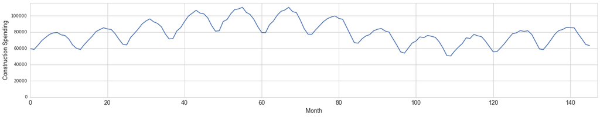

```python
x = df_con.index
y = df_con['Total Construction']
plt.figure(figsize=(24,4))               # figure must be resized prior to .plot() statement
plt.plot(x,y,label='Total Construction')
plt.xlabel('Month',fontsize=14)                      # Title for the horizontal axis
plt.ylabel('Construction Spending',fontsize=14)      # Title for the vertical axis
plt.axis([0,max(df_con['Month'])+1,0,max(df_con['Total Construction'])*1.05],fontsize=14)    # Set ranges of axes
plt.xticks(fontsize = 14)
plt.show()
```

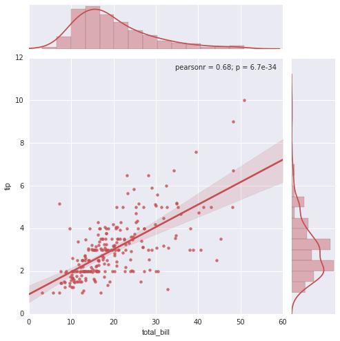

```python
import seaborn as sns
sns.set(style="whitegrid")

xs = [0,82.0442626658045,164.140532825633,249.101916493353,332.182520454561,416.254670963008,495.330844802651,575.152803567278,653.205144040749,738.002602107511,818.027625347191,898.118246791891,980.079475188722,1061.14169245002,1139.27372549306,1222.46124841828,1300.35875796241,1375.56916894815,1450.58381247379,1528.61926864683,1605.58397275636,1690.73526419816,1765.8607155748,1844.76374052086,1927.68455634244,2007.86892722346,2086.83606915306,2166.71913598734,2251.80135023691,2335.70816516882,2420.79263834332,2499.86354911873,2577.05890165442,2654.19208140119,2730.09283946298,2809.07577275313,2894.08624312766,2969.05670691318,3049.93958564477,3129.75861740531,3206.68277248806,3283.60346903165,3364.58552562287,3449.40362446521,3525.4406380069,3608.13685182861,3690.05929028829,3773.14656467608,3850.22786804579,3930.30737684189,4015.46434790825,4093.50879464788,4172.64841837878,4252.66450124259,4335.57956650011,4420.52164467734,4495.52991250898,4575.39742270308,4650.49642074232,4730.52574677055,4805.68851119975,4880.60019974235,4960.70865715944,5043.67168991259,5118.73724644963,5203.54753389807,5283.38430140739,5359.51383129058,5438.3504224767,5519.19106748314,5597.38879699402]
ys = [69,70.5331166725557,71.5580608629997,71.7925736363559,71.3468902075964,70.8280365103217,70.6414982437025,70.4451053764375,70.3795952412711,69.7645648576213,69.5426154537094,69.3004779067882,68.9026747371149,68.599154906399,68.519069857217,68.3772433121902,69.1486631584102,68.7548264957532,68.3609585242701,68.5575021969504,68.5786288310157,70.1801398605569,69.7914710297875,70.1491959166127,71.3308639026079,71.9361568322099,71.7841530239482,71.5632100706621,70.9532872882161,70.4120650812618,69.7956890967353,69.6193830861858,69.6154149236862,69.6130427165012,69.7102463368457,69.5264209638887,68.9050613087613,69.1051712486311,68.8193037564598,68.6066819000086,68.6092749335593,68.6204785117934,68.3360360051156,68.5812312774717,68.3713770000006,69.5440095449469,70.5260768620176,72.0285425812187,72.0349254824144,71.8158332177273,71.1892654017154,71.1169346409977,70.8948191898231,70.6895661675202,70.2298913978404,69.6255849641529,69.7340391269025,69.5070018796742,69.6617353391113,69.4627544694931,69.630774569752,69.8026157834872,69.5269217792645,69.0549816241028,69.1984712324886,68.3562401007611,68.1422906748129,68.2062726166005,68.0498033914326,68.6018257745021,68.7606159741864]


#import seaborn as sns
sns.set(style="darkgrid", color_codes=True)

tips = sns.load_dataset("tips")
g = sns.jointplot("total_bill", "tip", data=tips, kind="reg",
                  xlim=(0, 60), ylim=(0, 12), color="r", size=7)
```

```python
df_con.head()
```

|  | Month | Total Construction | Private Construction | Public Construction |
| --- | --- | --- | --- | --- |
| 0 | 1 | 59516 | 45273 | 14243 |
| 1 | 2 | 58588 | 44475 | 14113 |
| 2 | 3 | 63782 | 49396 | 14386 |
| 3 | 4 | 69504 | 53283 | 16221 |
| 4 | 5 | 73384 | 55009 | 18375 |